# Perwalian Semester 1 Angkatan 2024 | S2 Statistika Terapan FMIPA Unpad

**S2 Statistika Terapan FMIPA Unpad** Pasca Sarjana Statistika · Universitas Padjadjaran

master.statistics.unpad.ac.id

[figure not shown]

Berita Akademik · Perwalian Bersama

# Perwalian Semester 1 Angkatan 2024

Pengenalan Kurikulum 2023, strategi pembelajaran selama menempuh pendidikan magister, perencanaan publikasi ilmiah, serta penguatan pemahaman visi dan misi program studi.

Kamis, 15 Agustus 2024 Ganjil 2024/2025 Departemen Statistika FMIPA Unpad Dilanjutkan di Resto Sari Kedalai

[figure not shown]

Angkatan**Mahasiswa Angkatan 2024**

Semester**Semester 1 · Ganjil 2024/2025**

Kurikulum**Kurikulum 2023 · Minimum 36 SKS**

Beban Semester 1**18 SKS · Enam mata kuliah**

## Mengawali perkuliahan dengan arah akademik yang jelas

Program Studi Magister Statistika Terapan FMIPA Universitas Padjadjaran menyelenggarakan kegiatan perwalian bersama mahasiswa Angkatan 2024 pada **Kamis, 15 Agustus 2024**. Kegiatan dilaksanakan secara luring di Gedung Departemen Statistika FMIPA Unpad dan dilanjutkan dengan makan siang bersama di **Resto Sari Kedalai**.

Perwalian dipimpin oleh Ketua Program Studi S2 Statistika Terapan, **I Gede Nyoman Mindra Jaya**. Pertemuan ini menjadi bagian penting dalam memperkenalkan sistem akademik, struktur kurikulum, pola pembelajaran, target capaian studi, dan budaya akademik yang perlu dibangun mahasiswa sejak awal semester.

**Fokus utama perwalian:** mahasiswa diharapkan tidak sekadar menyelesaikan mata kuliah, tetapi membangun kompetensi statistika terapan, keterampilan komputasi, kemampuan menulis ilmiah, integritas akademik, serta kesiapan menghasilkan publikasi dan tesis yang bermutu.

## Kurikulum 2023 minimum 36 SKS

Kurikulum dirancang agar mahasiswa memiliki keseimbangan antara penguasaan teori, kemampuan menerapkan metode pada persoalan nyata, kompetensi komputasi, dan kesiapan melakukan penelitian secara mandiri.

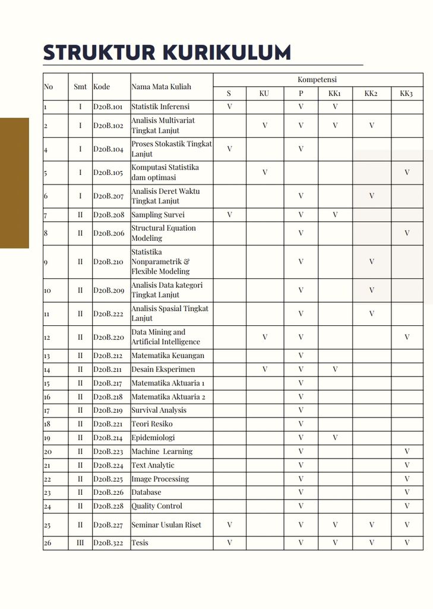

Struktur mata kuliah Kurikulum 2023 Program Studi Magister Statistika Terapan.

## Beban studi Semester 1: 18 SKS

Pada Semester 1, mahasiswa mengambil enam mata kuliah dengan total **18 SKS**. Mata kuliah tersebut memberikan fondasi utama untuk memahami inferensi, pemodelan, komputasi, proses stokastik, dan analisis data tingkat lanjut.

| No. | Mata Kuliah | Format SKS | Total |
| --- | --- | --- | --- |
| 1 | Statistik Inferensi | 3 (3+0) | 3 |
| 2 | Analisis Data Multivariat Tingkat Lanjut | 3 (2+1) | 3 |
| 3 | Analisis Regresi Tingkat Lanjut | 3 (2+1) | 3 |
| 4 | Proses Stokastik Tingkat Lanjut | 3 (3+0) | 3 |
| 5 | Komputasi Statistik dan Optimasi | 3 (1+2) | 3 |
| 6 | Analisis Data Deret Waktu Tingkat Lanjut | 3 (2+1) | 3 |
| Total Semester 1 |  |  | 18 SKS |

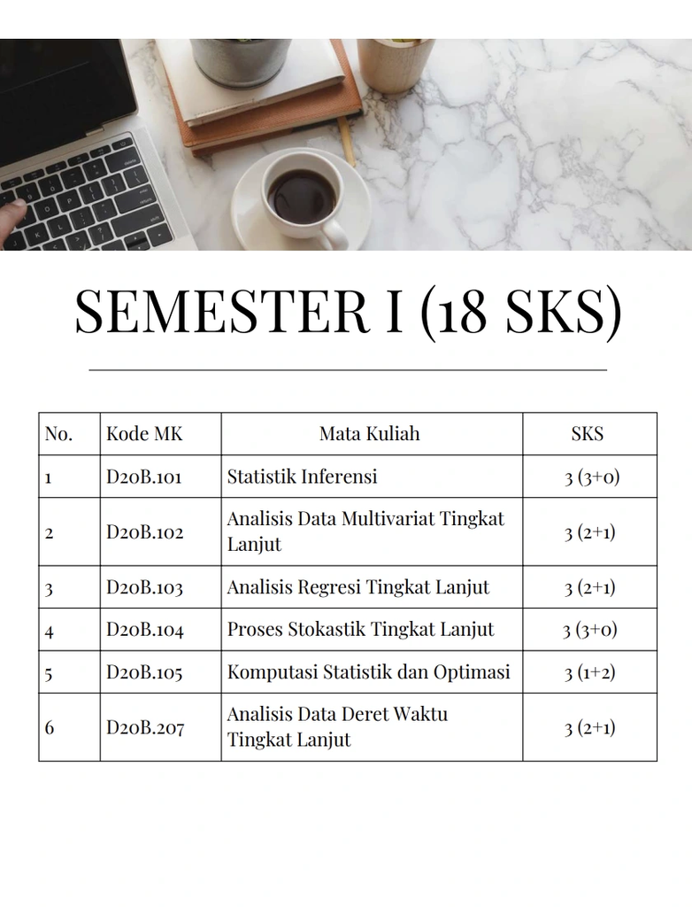

Enam mata kuliah Semester 1 dengan beban studi keseluruhan 18 SKS.

## Visi dan misi program studi

Mahasiswa juga memperoleh penjelasan mengenai visi dan misi yang menjadi arah penyelenggaraan pendidikan di Program Studi Magister Statistika Terapan. Pemahaman terhadap visi dan misi diperlukan agar mahasiswa melihat keterkaitan antara proses perkuliahan, kegiatan penelitian, publikasi ilmiah, serta kontribusi statistika bagi penyelesaian persoalan nyata.

Visi **Pusat pengembangan disiplin ilmu statistika yang memadukan teori dan aplikasinya.**

Visi menekankan dukungan terhadap pengembangan Universitas Padjadjaran sebagai universitas berbasis riset dan pusat pendidikan statistika lanjutan yang memperoleh rekognisi internasional.

Misi **Pendidikan, penelitian, pengabdian, dan publikasi ilmiah yang relevan.**

Misi mencakup pendidikan yang memenuhi tuntutan pengguna, pengembangan tema penelitian statistika, serta diseminasi hasil pemikiran melalui publikasi ilmiah.

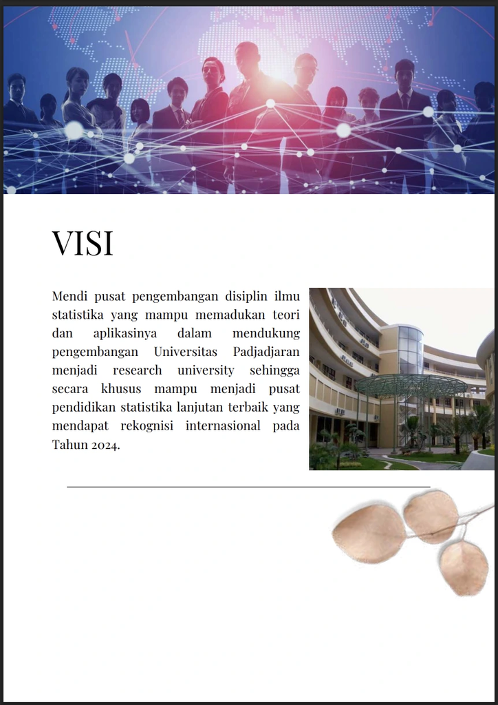

Dokumen visi yang menjadi bagian dari pengenalan arah akademik program studi.

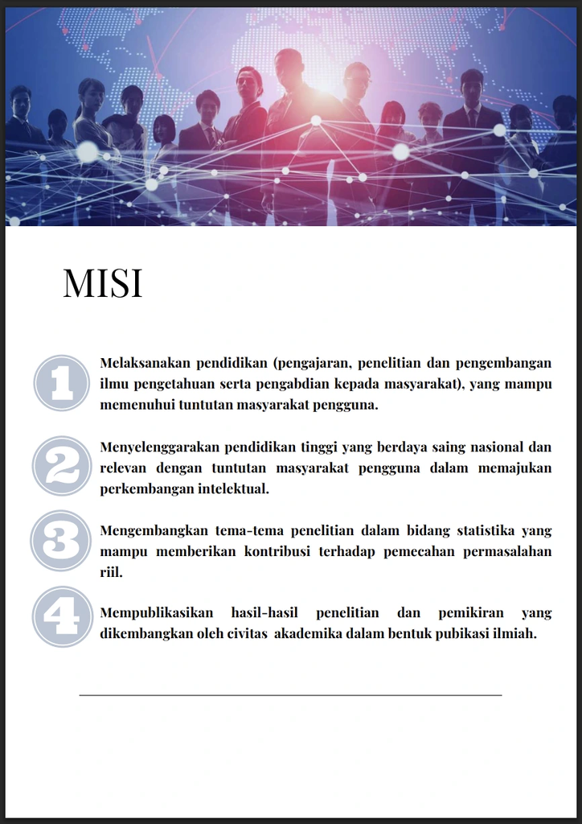

Dokumen misi yang menekankan pendidikan, penelitian, pengabdian, dan publikasi ilmiah.

## Strategi pembelajaran selama studi

Mahasiswa diarahkan untuk membangun pola belajar yang aktif, konsisten, dan berbasis pemecahan masalah. Perkuliahan magister menuntut kemampuan membaca sumber ilmiah, memahami landasan metode, menggunakan perangkat komputasi, serta menjelaskan hasil analisis secara benar dan komunikatif.

**Kelola waktu sejak awal** Susun target mingguan untuk membaca, berlatih komputasi, menyelesaikan tugas, dan meninjau kembali materi.

**Aktif berdiskusi** Gunakan ruang kelas, kelompok belajar, dan konsultasi dosen untuk memperjelas konsep yang kompleks.

**Hubungkan teori dengan data** Setiap metode perlu dipahami melalui penerapan, interpretasi, dan evaluasi terhadap persoalan nyata.

**Bangun keterampilan komputasi** Kode, data, dan hasil analisis perlu dikelola secara rapi agar proses kerja dapat diperiksa dan direproduksi.

**Jaga integritas akademik** Gunakan sumber secara bertanggung jawab, kutip referensi dengan benar, dan hindari manipulasi hasil.

**Mulai merancang topik riset** Identifikasi bidang minat, calon data, metode, dan masalah substantif yang berpotensi dikembangkan menjadi tesis.

## Strategi publikasi ilmiah

Perwalian juga membahas pentingnya menyiapkan publikasi sejak awal masa studi. Mahasiswa didorong untuk membaca artikel ilmiah secara rutin, mengenali kesenjangan penelitian, memilih topik yang memiliki kontribusi jelas, serta membangun kebiasaan menulis secara bertahap.

Strategi publikasi perlu dimulai dari pemilihan masalah yang relevan, penyusunan metode yang dapat dipertanggungjawabkan, pengelolaan data dan kode secara transparan, pemilihan jurnal yang sesuai ruang lingkup, serta kepatuhan pada etika kepengarangan dan publikasi. Publikasi diposisikan sebagai bagian dari proses akademik, bukan sekadar target administratif.

[figure not shown]

Suasana kebersamaan dan diskusi mahasiswa Angkatan 2024 setelah pengarahan akademik.

## Ditutup dengan makan siang bersama

Setelah sesi perwalian di Gedung Departemen Statistika selesai, kegiatan dilanjutkan dengan makan siang bersama di Resto Sari Kedalai. Suasana yang lebih santai memberikan ruang bagi mahasiswa untuk saling mengenal, membangun kebersamaan angkatan, dan berdiskusi langsung mengenai pengalaman awal menjalani perkuliahan.

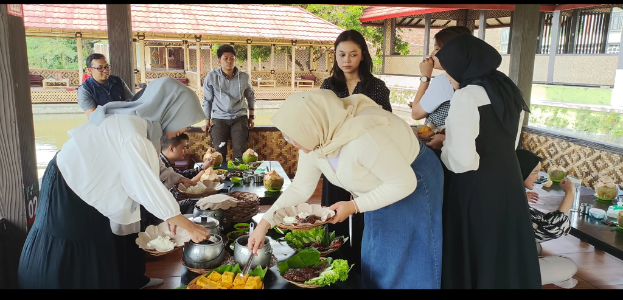

Makan siang bersama sebagai penutup rangkaian perwalian Semester 1 Angkatan 2024.

Melalui perwalian ini, mahasiswa diharapkan memahami struktur Kurikulum 2023, mampu mengelola beban studi Semester 1 secara baik, membangun strategi belajar yang konsisten, dan mulai menyiapkan perjalanan penelitian serta publikasi ilmiah sejak awal masa studi.

### Pimpinan kegiatan

Ketua Program Studi **I Gede Nyoman Mindra Jaya** S2 Statistika Terapan FMIPA Unpad

### Mahasiswa yang hadir

- SSyahla Anisah
- IInu Alifiyah Phalufi
- MMuhamad Ramdhani
- AAgy Aswad Ilham
- JJesicha Aulia Adam
- MMuhammad Restu Agam
- NNisa Akbarilah Putri
- AAnindya Nitisari
- LLeivina Saliaputri
- GGracia Joanne Crissan BR Hutabarat
- AAnggie Alnurin Prasetya
- DDisa Rahma Kirana
- NNisrina Aprilia Kamila
- LLuri Zahara
- MMuhammad Sahid

Total mahasiswa hadir: 15 orang

Dokumentasi kegiatan